# Springboard Data Science Career Track Unit 4 Challenge - Tier 3 Complete

## Objectives

Hey! Great job getting through those challenging DataCamp courses. You're learning a lot in a short span of time.

In this notebook, you're going to apply the skills you've been learning, bridging the gap between the controlled environment of DataCamp and the *slightly* messier work that data scientists do with actual datasets!

Here’s the mystery we’re going to solve: *which boroughs of London have seen the greatest increase in housing prices, on average, over the last two decades?*

A borough is just a fancy word for district. You may be familiar with the five boroughs of New York… well, there are 32 boroughs within Greater London [(here's some info for the curious)](https://en.wikipedia.org/wiki/London_boroughs). Some of them are more desirable areas to live in, and the data will reflect that with a greater rise in housing prices.

*This is the Tier 3 notebook, which means it's not filled in at all: we'll just give you the skeleton of a project, the brief and the data. It's up to you to play around with it and see what you can find out! Good luck! If you struggle, feel free to look at easier tiers for help; but try to dip in and out of them, as the more independent work you do, the better it is for your learning!*

This challenge will make use of only what you learned in the following DataCamp courses:

- Prework courses (Introduction to Python for Data Science, Intermediate Python for Data Science)
- Data Types for Data Science
- Python Data Science Toolbox (Part One)
- pandas Foundations
- Manipulating DataFrames with pandas
- Merging DataFrames with pandas

Of the tools, techniques and concepts in the above DataCamp courses, this challenge should require the application of the following:

- **pandas**
  - **data ingestion and inspection** (pandas Foundations, Module One)
  - **exploratory data analysis** (pandas Foundations, Module Two)
  - **tidying and cleaning** (Manipulating DataFrames with pandas, Module Three)
  - **transforming DataFrames** (Manipulating DataFrames with pandas, Module One)
  - **subsetting DataFrames with lists** (Manipulating DataFrames with pandas, Module One)
  - **filtering DataFrames** (Manipulating DataFrames with pandas, Module One)
  - **grouping data** (Manipulating DataFrames with pandas, Module Four)
  - **melting data** (Manipulating DataFrames with pandas, Module Three)
  - **advanced indexing** (Manipulating DataFrames with pandas, Module Four)
- **matplotlib** (Intermediate Python for Data Science, Module One)
- **fundamental data types** (Data Types for Data Science, Module One)
- **dictionaries** (Intermediate Python for Data Science, Module Two)
- **handling dates and times** (Data Types for Data Science, Module Four)
- **function definition** (Python Data Science Toolbox - Part One, Module One)
- **default arguments, variable length, and scope** (Python Data Science Toolbox - Part One, Module Two)
- **lambda functions and error handling** (Python Data Science Toolbox - Part One, Module Four)

## The Data Science Pipeline

This is Tier Three, so we'll get you started. But after that, it's all in your hands! When you feel done with your investigations, look back over what you've accomplished, and prepare a quick presentation of your findings for the next mentor meeting.

Data Science is magical. In this case study, you'll get to apply some complex machine learning algorithms. But as [David Spiegelhalter](https://www.youtube.com/watch?v=oUs1uvsz0Ok) reminds us, there is no substitute for simply **taking a really, really good look at the data.** Sometimes, this is all we need to answer our question.

Data Science projects generally adhere to the four stages of Data Science Pipeline:

1. Sourcing and loading
2. Cleaning, transforming, and visualizing
3. Modeling
4. Evaluating and concluding

### 1. Sourcing and Loading

Any Data Science project kicks off by importing *pandas*. The documentation of this wonderful library can be found [here](https://pandas.pydata.org/). As you've seen, pandas is conveniently connected to the [Numpy](http://www.numpy.org/) and [Matplotlib](https://matplotlib.org/) libraries.

*Hint:* This part of the data science pipeline will test those skills you acquired in the pandas Foundations course, Module One.

#### 1.1. Importing Libraries

```python
# Let's import the pandas, numpy libraries as pd, and np respectively.
import pandas as pd
import numpy as np

# Load the pyplot collection of functions from matplotlib, as plt
import matplotlib.pyplot as plt
```

#### 1.2. Loading the data

Your data comes from the [London Datastore](https://data.london.gov.uk/): a free, open-source data-sharing portal for London-oriented datasets.

```python
# First, make a variable called url_LondonHousePrices, and assign it the following link, enclosed in quotation-marks as a string:
# https://data.london.gov.uk/download/uk-house-price-index/70ac0766-8902-4eb5-aab5-01951aaed773/UK%20House%20price%20index.xls

url_LondonHousePrices = "https://data.london.gov.uk/download/uk-house-price-index/70ac0766-8902-4eb5-aab5-01951aaed773/UK%20House%20price%20index.xls"

# The dataset we're interested in contains the Average prices of the houses, and is actually on a particular sheet of the Excel file.
# As a result, we need to specify the sheet name in the read_excel() method.
# Put this data into a variable called properties.
properties = pd.read_excel(url_LondonHousePrices, sheet_name='Average price', index_col= None)
```

### 2. Cleaning, transforming, and visualizing

This second stage is arguably the most important part of any Data Science project. The first thing to do is take a proper look at the data. Cleaning forms the majority of this stage, and can be done both before or after Transformation.

The end goal of data cleaning is to have tidy data. When data is tidy:

1. Each variable has a column.
2. Each observation forms a row.

Keep the end goal in mind as you move through this process, every step will take you closer.

*Hint:* This part of the data science pipeline should test those skills you acquired in:

- Intermediate Python for data science, all modules.
- pandas Foundations, all modules.
- Manipulating DataFrames with pandas, all modules.
- Data Types for Data Science, Module Four.
- Python Data Science Toolbox - Part One, all modules

**2.1. Exploring your data**

Think about your pandas functions for checking out a dataframe.

```python
#checking shape of the dataframe
properties.shape
```

```
(311, 49)
```

```python
# checkin first few rows of the dataframe
properties.head()
```

|  | Unnamed: 0 | City of London | Barking & Dagenham | Barnet | Bexley | Brent | Bromley | Camden | Croydon | Ealing | ... | NORTH WEST | YORKS & THE HUMBER | EAST MIDLANDS | WEST MIDLANDS | EAST OF ENGLAND | LONDON | SOUTH EAST | SOUTH WEST | Unnamed: 47 | England |
| --- | --- | --- | --- | --- | --- | --- | --- | --- | --- | --- | --- | --- | --- | --- | --- | --- | --- | --- | --- | --- | --- |
| 0 | NaT | E09000001 | E09000002 | E09000003 | E09000004 | E09000005 | E09000006 | E09000007 | E09000008 | E09000009 | ... | E12000002 | E12000003 | E12000004 | E12000005 | E12000006 | E12000007 | E12000008 | E12000009 | NaN | E92000001 |
| 1 | 1995-01-01 | 91449 | 50460.2 | 93284.5 | 64958.1 | 71306.6 | 81671.5 | 120933 | 69158.2 | 79885.9 | ... | 43958.5 | 44803.4 | 45544.5 | 48527.5 | 56701.6 | 74435.8 | 64018.9 | 54705.2 | NaN | 53202.8 |
| 2 | 1995-02-01 | 82202.8 | 51085.8 | 93190.2 | 64787.9 | 72022.3 | 81657.6 | 119509 | 68951.1 | 80897.1 | ... | 43925.4 | 44528.8 | 46051.6 | 49341.3 | 56593.6 | 72777.9 | 63715 | 54356.1 | NaN | 53096.2 |
| 3 | 1995-03-01 | 79120.7 | 51269 | 92247.5 | 64367.5 | 72015.8 | 81449.3 | 120282 | 68712.4 | 81379.9 | ... | 44434.9 | 45200.5 | 45383.8 | 49442.2 | 56171.2 | 73896.8 | 64113.6 | 53583.1 | NaN | 53201.3 |
| 4 | 1995-04-01 | 77101.2 | 53133.5 | 90762.9 | 64277.7 | 72965.6 | 81124.4 | 120098 | 68610 | 82188.9 | ... | 44267.8 | 45614.3 | 46124.2 | 49455.9 | 56567.9 | 74455.3 | 64623.2 | 54786 | NaN | 53590.9 |

5 rows × 49 columns

```python
# just copying original so that the original remains intact
prop1 = properties.copy()
```

**2.2. Cleaning the data**

You might find you need to transpose your dataframe, check out what its row indexes are, and reset the index. You also might find you need to assign the values of the first row to your column headings . (Hint: recall the .columns feature of DataFrames, as well as the iloc[] method).

Don't be afraid to use StackOverflow for help with this.

```python
# Transposing the dataframe
prop_2 = prop1.T
```

```python
prop_2.head()
```

|  | 0 | 1 | 2 | 3 | 4 | 5 | 6 | 7 | 8 | 9 | ... | 301 | 302 | 303 | 304 | 305 | 306 | 307 | 308 | 309 | 310 |
| --- | --- | --- | --- | --- | --- | --- | --- | --- | --- | --- | --- | --- | --- | --- | --- | --- | --- | --- | --- | --- | --- |
| Unnamed: 0 | NaT | 1995-01-01 00:00:00 | 1995-02-01 00:00:00 | 1995-03-01 00:00:00 | 1995-04-01 00:00:00 | 1995-05-01 00:00:00 | 1995-06-01 00:00:00 | 1995-07-01 00:00:00 | 1995-08-01 00:00:00 | 1995-09-01 00:00:00 | ... | 2020-01-01 00:00:00 | 2020-02-01 00:00:00 | 2020-03-01 00:00:00 | 2020-04-01 00:00:00 | 2020-05-01 00:00:00 | 2020-06-01 00:00:00 | 2020-07-01 00:00:00 | 2020-08-01 00:00:00 | 2020-09-01 00:00:00 | 2020-10-01 00:00:00 |
| City of London | E09000001 | 91449 | 82202.8 | 79120.7 | 77101.2 | 84409.1 | 94900.5 | 110128 | 112329 | 104473 | ... | 773679 | 792769 | 828658 | 900126 | 904803 | 869929 | 785001 | 794881 | 768714 | 721490 |
| Barking & Dagenham | E09000002 | 50460.2 | 51085.8 | 51269 | 53133.5 | 53042.2 | 53700.3 | 52113.1 | 52232.2 | 51471.6 | ... | 303054 | 302748 | 301570 | 293553 | 292478 | 299074 | 303701 | 304696 | 301170 | 308583 |
| Barnet | E09000003 | 93284.5 | 93190.2 | 92247.5 | 90762.9 | 90258 | 90107.2 | 91441.2 | 92361.3 | 93273.1 | ... | 521612 | 516411 | 522770 | 529115 | 527494 | 517266 | 521528 | 525762 | 535663 | 536263 |
| Bexley | E09000004 | 64958.1 | 64787.9 | 64367.5 | 64277.7 | 63997.1 | 64252.3 | 63722.7 | 64432.6 | 64509.5 | ... | 336863 | 338817 | 339095 | 341997 | 338857 | 340723 | 343385 | 348046 | 345461 | 344254 |

5 rows × 311 columns

```python
# Checking index values
prop_2.index
```

```
Index(['Unnamed: 0', 'City of London', 'Barking & Dagenham', 'Barnet',
       'Bexley', 'Brent', 'Bromley', 'Camden', 'Croydon', 'Ealing', 'Enfield',
       'Greenwich', 'Hackney', 'Hammersmith & Fulham', 'Haringey', 'Harrow',
       'Havering', 'Hillingdon', 'Hounslow', 'Islington',
       'Kensington & Chelsea', 'Kingston upon Thames', 'Lambeth', 'Lewisham',
       'Merton', 'Newham', 'Redbridge', 'Richmond upon Thames', 'Southwark',
       'Sutton', 'Tower Hamlets', 'Waltham Forest', 'Wandsworth',
       'Westminster', 'Unnamed: 34', 'Inner London', 'Outer London',
       'Unnamed: 37', 'NORTH EAST', 'NORTH WEST', 'YORKS & THE HUMBER',
       'EAST MIDLANDS', 'WEST MIDLANDS', 'EAST OF ENGLAND', 'LONDON',
       'SOUTH EAST', 'SOUTH WEST', 'Unnamed: 47', 'England'],
      dtype='object')
```

```python
# resetting index
prop_2 = prop_2.reset_index()
```

```python
prop_2.index
```

```
RangeIndex(start=0, stop=49, step=1)
```

```python
prop_2.head()
```

|  | index | 0 | 1 | 2 | 3 | 4 | 5 | 6 | 7 | 8 | ... | 301 | 302 | 303 | 304 | 305 | 306 | 307 | 308 | 309 | 310 |
| --- | --- | --- | --- | --- | --- | --- | --- | --- | --- | --- | --- | --- | --- | --- | --- | --- | --- | --- | --- | --- | --- |
| 0 | Unnamed: 0 | NaT | 1995-01-01 00:00:00 | 1995-02-01 00:00:00 | 1995-03-01 00:00:00 | 1995-04-01 00:00:00 | 1995-05-01 00:00:00 | 1995-06-01 00:00:00 | 1995-07-01 00:00:00 | 1995-08-01 00:00:00 | ... | 2020-01-01 00:00:00 | 2020-02-01 00:00:00 | 2020-03-01 00:00:00 | 2020-04-01 00:00:00 | 2020-05-01 00:00:00 | 2020-06-01 00:00:00 | 2020-07-01 00:00:00 | 2020-08-01 00:00:00 | 2020-09-01 00:00:00 | 2020-10-01 00:00:00 |
| 1 | City of London | E09000001 | 91449 | 82202.8 | 79120.7 | 77101.2 | 84409.1 | 94900.5 | 110128 | 112329 | ... | 773679 | 792769 | 828658 | 900126 | 904803 | 869929 | 785001 | 794881 | 768714 | 721490 |
| 2 | Barking & Dagenham | E09000002 | 50460.2 | 51085.8 | 51269 | 53133.5 | 53042.2 | 53700.3 | 52113.1 | 52232.2 | ... | 303054 | 302748 | 301570 | 293553 | 292478 | 299074 | 303701 | 304696 | 301170 | 308583 |
| 3 | Barnet | E09000003 | 93284.5 | 93190.2 | 92247.5 | 90762.9 | 90258 | 90107.2 | 91441.2 | 92361.3 | ... | 521612 | 516411 | 522770 | 529115 | 527494 | 517266 | 521528 | 525762 | 535663 | 536263 |
| 4 | Bexley | E09000004 | 64958.1 | 64787.9 | 64367.5 | 64277.7 | 63997.1 | 64252.3 | 63722.7 | 64432.6 | ... | 336863 | 338817 | 339095 | 341997 | 338857 | 340723 | 343385 | 348046 | 345461 | 344254 |

5 rows × 312 columns

```python
prop_2.columns
```

```
Index(['index',       0,       1,       2,       3,       4,       5,       6,
             7,       8,
       ...
           301,     302,     303,     304,     305,     306,     307,     308,
           309,     310],
      dtype='object', length=312)
```

```python
# Assigning first row as the column headers
prop_2.columns = prop_2.iloc[0]
```

```python
prop_2.head()
```

|  | Unnamed: 0 | NaT | 1995-01-01 00:00:00 | 1995-02-01 00:00:00 | 1995-03-01 00:00:00 | 1995-04-01 00:00:00 | 1995-05-01 00:00:00 | 1995-06-01 00:00:00 | 1995-07-01 00:00:00 | 1995-08-01 00:00:00 | ... | 2020-01-01 00:00:00 | 2020-02-01 00:00:00 | 2020-03-01 00:00:00 | 2020-04-01 00:00:00 | 2020-05-01 00:00:00 | 2020-06-01 00:00:00 | 2020-07-01 00:00:00 | 2020-08-01 00:00:00 | 2020-09-01 00:00:00 | 2020-10-01 00:00:00 |
| --- | --- | --- | --- | --- | --- | --- | --- | --- | --- | --- | --- | --- | --- | --- | --- | --- | --- | --- | --- | --- | --- |
| 0 | Unnamed: 0 | NaT | 1995-01-01 00:00:00 | 1995-02-01 00:00:00 | 1995-03-01 00:00:00 | 1995-04-01 00:00:00 | 1995-05-01 00:00:00 | 1995-06-01 00:00:00 | 1995-07-01 00:00:00 | 1995-08-01 00:00:00 | ... | 2020-01-01 00:00:00 | 2020-02-01 00:00:00 | 2020-03-01 00:00:00 | 2020-04-01 00:00:00 | 2020-05-01 00:00:00 | 2020-06-01 00:00:00 | 2020-07-01 00:00:00 | 2020-08-01 00:00:00 | 2020-09-01 00:00:00 | 2020-10-01 00:00:00 |
| 1 | City of London | E09000001 | 91449 | 82202.8 | 79120.7 | 77101.2 | 84409.1 | 94900.5 | 110128 | 112329 | ... | 773679 | 792769 | 828658 | 900126 | 904803 | 869929 | 785001 | 794881 | 768714 | 721490 |
| 2 | Barking & Dagenham | E09000002 | 50460.2 | 51085.8 | 51269 | 53133.5 | 53042.2 | 53700.3 | 52113.1 | 52232.2 | ... | 303054 | 302748 | 301570 | 293553 | 292478 | 299074 | 303701 | 304696 | 301170 | 308583 |
| 3 | Barnet | E09000003 | 93284.5 | 93190.2 | 92247.5 | 90762.9 | 90258 | 90107.2 | 91441.2 | 92361.3 | ... | 521612 | 516411 | 522770 | 529115 | 527494 | 517266 | 521528 | 525762 | 535663 | 536263 |
| 4 | Bexley | E09000004 | 64958.1 | 64787.9 | 64367.5 | 64277.7 | 63997.1 | 64252.3 | 63722.7 | 64432.6 | ... | 336863 | 338817 | 339095 | 341997 | 338857 | 340723 | 343385 | 348046 | 345461 | 344254 |

5 rows × 312 columns

**2.3. Cleaning the data (part 2)**

You might we have to **rename** a couple columns. How do you do this? The clue's pretty bold...

```python
# Deleting the first row which is same as headers
prop_2 = prop_2.drop(0)
```

```python
prop_2.head()
```

|  | Unnamed: 0 | NaT | 1995-01-01 00:00:00 | 1995-02-01 00:00:00 | 1995-03-01 00:00:00 | 1995-04-01 00:00:00 | 1995-05-01 00:00:00 | 1995-06-01 00:00:00 | 1995-07-01 00:00:00 | 1995-08-01 00:00:00 | ... | 2020-01-01 00:00:00 | 2020-02-01 00:00:00 | 2020-03-01 00:00:00 | 2020-04-01 00:00:00 | 2020-05-01 00:00:00 | 2020-06-01 00:00:00 | 2020-07-01 00:00:00 | 2020-08-01 00:00:00 | 2020-09-01 00:00:00 | 2020-10-01 00:00:00 |
| --- | --- | --- | --- | --- | --- | --- | --- | --- | --- | --- | --- | --- | --- | --- | --- | --- | --- | --- | --- | --- | --- |
| 1 | City of London | E09000001 | 91449 | 82202.8 | 79120.7 | 77101.2 | 84409.1 | 94900.5 | 110128 | 112329 | ... | 773679 | 792769 | 828658 | 900126 | 904803 | 869929 | 785001 | 794881 | 768714 | 721490 |
| 2 | Barking & Dagenham | E09000002 | 50460.2 | 51085.8 | 51269 | 53133.5 | 53042.2 | 53700.3 | 52113.1 | 52232.2 | ... | 303054 | 302748 | 301570 | 293553 | 292478 | 299074 | 303701 | 304696 | 301170 | 308583 |
| 3 | Barnet | E09000003 | 93284.5 | 93190.2 | 92247.5 | 90762.9 | 90258 | 90107.2 | 91441.2 | 92361.3 | ... | 521612 | 516411 | 522770 | 529115 | 527494 | 517266 | 521528 | 525762 | 535663 | 536263 |
| 4 | Bexley | E09000004 | 64958.1 | 64787.9 | 64367.5 | 64277.7 | 63997.1 | 64252.3 | 63722.7 | 64432.6 | ... | 336863 | 338817 | 339095 | 341997 | 338857 | 340723 | 343385 | 348046 | 345461 | 344254 |
| 5 | Brent | E09000005 | 71306.6 | 72022.3 | 72015.8 | 72965.6 | 73704 | 74310.5 | 74127 | 73547 | ... | 428436 | 469962 | 465941 | 469583 | 481570 | 485388 | 485619 | 496606 | 522546 | 518636 |

5 rows × 312 columns

```python
prop_2.info()
```

```
<class 'pandas.core.frame.DataFrame'>
Int64Index: 48 entries, 1 to 48
Columns: 312 entries, Unnamed: 0 to 2020-10-01 00:00:00
dtypes: object(312)
memory usage: 117.4+ KB
```

```python
# Renaming columns
prop_2 = prop_2.rename(columns = {'Unnamed: 0': 'London_borough', pd.NaT : "Id"})
```

```python
prop_2.head()
```

|  | London_borough | Id | 1995-01-01 00:00:00 | 1995-02-01 00:00:00 | 1995-03-01 00:00:00 | 1995-04-01 00:00:00 | 1995-05-01 00:00:00 | 1995-06-01 00:00:00 | 1995-07-01 00:00:00 | 1995-08-01 00:00:00 | ... | 2020-01-01 00:00:00 | 2020-02-01 00:00:00 | 2020-03-01 00:00:00 | 2020-04-01 00:00:00 | 2020-05-01 00:00:00 | 2020-06-01 00:00:00 | 2020-07-01 00:00:00 | 2020-08-01 00:00:00 | 2020-09-01 00:00:00 | 2020-10-01 00:00:00 |
| --- | --- | --- | --- | --- | --- | --- | --- | --- | --- | --- | --- | --- | --- | --- | --- | --- | --- | --- | --- | --- | --- |
| 1 | City of London | E09000001 | 91449 | 82202.8 | 79120.7 | 77101.2 | 84409.1 | 94900.5 | 110128 | 112329 | ... | 773679 | 792769 | 828658 | 900126 | 904803 | 869929 | 785001 | 794881 | 768714 | 721490 |
| 2 | Barking & Dagenham | E09000002 | 50460.2 | 51085.8 | 51269 | 53133.5 | 53042.2 | 53700.3 | 52113.1 | 52232.2 | ... | 303054 | 302748 | 301570 | 293553 | 292478 | 299074 | 303701 | 304696 | 301170 | 308583 |
| 3 | Barnet | E09000003 | 93284.5 | 93190.2 | 92247.5 | 90762.9 | 90258 | 90107.2 | 91441.2 | 92361.3 | ... | 521612 | 516411 | 522770 | 529115 | 527494 | 517266 | 521528 | 525762 | 535663 | 536263 |
| 4 | Bexley | E09000004 | 64958.1 | 64787.9 | 64367.5 | 64277.7 | 63997.1 | 64252.3 | 63722.7 | 64432.6 | ... | 336863 | 338817 | 339095 | 341997 | 338857 | 340723 | 343385 | 348046 | 345461 | 344254 |
| 5 | Brent | E09000005 | 71306.6 | 72022.3 | 72015.8 | 72965.6 | 73704 | 74310.5 | 74127 | 73547 | ... | 428436 | 469962 | 465941 | 469583 | 481570 | 485388 | 485619 | 496606 | 522546 | 518636 |

5 rows × 312 columns

```python
prop_2.shape
```

```
(48, 312)
```

**2.4.Transforming the data**

Remember what Wes McKinney said about tidy data?

You might need to **melt** your DataFrame here.

```python
# Melting datframe to get it into long format
prop_m = pd.melt(prop_2, id_vars = ['London_borough', 'Id'], var_name = 'Month', value_name = 'Avg Price')
```

```python
prop_m.head()
```

|  | London_borough | Id | Month | Avg Price |
| --- | --- | --- | --- | --- |
| 0 | City of London | E09000001 | 1995-01-01 | 91449 |
| 1 | Barking & Dagenham | E09000002 | 1995-01-01 | 50460.2 |
| 2 | Barnet | E09000003 | 1995-01-01 | 93284.5 |
| 3 | Bexley | E09000004 | 1995-01-01 | 64958.1 |
| 4 | Brent | E09000005 | 1995-01-01 | 71306.6 |

```python
prop_m.shape
```

```
(14880, 4)
```

Remember to make sure your column data types are all correct. Average prices, for example, should be floating point numbers...

```python
prop_m['Avg Price'] = prop_m['Avg Price'].astype(float).apply(lambda x: round(x,2))
```

```python
prop_m.head()
```

|  | London_borough | Id | Month | Avg Price |
| --- | --- | --- | --- | --- |
| 0 | City of London | E09000001 | 1995-01-01 | 91448.98 |
| 1 | Barking & Dagenham | E09000002 | 1995-01-01 | 50460.23 |
| 2 | Barnet | E09000003 | 1995-01-01 | 93284.52 |
| 3 | Bexley | E09000004 | 1995-01-01 | 64958.09 |
| 4 | Brent | E09000005 | 1995-01-01 | 71306.57 |

```python
prop_m.dtypes
```

```
London_borough            object
Id                        object
Month             datetime64[ns]
Avg Price                float64
dtype: object
```

**2.5. Cleaning the data (part 3)**

Do we have an equal number of observations in the ID, Average Price, Month, and London Borough columns? Remember that there are only 32 London Boroughs. How many entries do you have in that column?

Check out the contents of the London Borough column, and if you find null values, get rid of them however you see fit.

```python
# Getting unique Borough names
prop_m['London_borough'].unique()
```

```
array(['City of London', 'Barking & Dagenham', 'Barnet', 'Bexley',
       'Brent', 'Bromley', 'Camden', 'Croydon', 'Ealing', 'Enfield',
       'Greenwich', 'Hackney', 'Hammersmith & Fulham', 'Haringey',
       'Harrow', 'Havering', 'Hillingdon', 'Hounslow', 'Islington',
       'Kensington & Chelsea', 'Kingston upon Thames', 'Lambeth',
       'Lewisham', 'Merton', 'Newham', 'Redbridge',
       'Richmond upon Thames', 'Southwark', 'Sutton', 'Tower Hamlets',
       'Waltham Forest', 'Wandsworth', 'Westminster', 'Unnamed: 34',
       'Inner London', 'Outer London', 'Unnamed: 37', 'NORTH EAST',
       'NORTH WEST', 'YORKS & THE HUMBER', 'EAST MIDLANDS',
       'WEST MIDLANDS', 'EAST OF ENGLAND', 'LONDON', 'SOUTH EAST',
       'SOUTH WEST', 'Unnamed: 47', 'England'], dtype=object)
```

```python
prop_m[prop_m['London_borough'] == 'Unnamed: 34'].head()
```

[output not shown]

```python
# checking null values
prop_m[prop_m['Avg Price'].isna()].count()
```

```
London_borough    930
Id                  0
Month             930
Avg Price           0
dtype: int64
```

```python
# Dropping null value rows
prop_clear = prop_m.dropna()
```

```python
# Now we have same number of rows for all columns
prop_clear.count()
```

```
London_borough    13950
Id                13950
Month             13950
Avg Price         13950
dtype: int64
```

```python
prop_clear.head(50)
```

|  | London_borough | Id | Month | Avg Price |
| --- | --- | --- | --- | --- |
| 0 | City of London | E09000001 | 1995-01-01 | 91448.98 |
| 1 | Barking & Dagenham | E09000002 | 1995-01-01 | 50460.23 |
| 2 | Barnet | E09000003 | 1995-01-01 | 93284.52 |
| 3 | Bexley | E09000004 | 1995-01-01 | 64958.09 |
| 4 | Brent | E09000005 | 1995-01-01 | 71306.57 |
| 5 | Bromley | E09000006 | 1995-01-01 | 81671.48 |
| 6 | Camden | E09000007 | 1995-01-01 | 120932.89 |
| 7 | Croydon | E09000008 | 1995-01-01 | 69158.16 |
| 8 | Ealing | E09000009 | 1995-01-01 | 79885.89 |
| 9 | Enfield | E09000010 | 1995-01-01 | 72514.69 |
| 10 | Greenwich | E09000011 | 1995-01-01 | 62300.10 |
| 11 | Hackney | E09000012 | 1995-01-01 | 61296.53 |
| 12 | Hammersmith & Fulham | E09000013 | 1995-01-01 | 124902.86 |
| 13 | Haringey | E09000014 | 1995-01-01 | 76287.57 |
| 14 | Harrow | E09000015 | 1995-01-01 | 84769.53 |
| 15 | Havering | E09000016 | 1995-01-01 | 68000.14 |
| 16 | Hillingdon | E09000017 | 1995-01-01 | 73834.83 |
| 17 | Hounslow | E09000018 | 1995-01-01 | 72231.71 |
| 18 | Islington | E09000019 | 1995-01-01 | 92516.49 |
| 19 | Kensington & Chelsea | E09000020 | 1995-01-01 | 182694.83 |
| 20 | Kingston upon Thames | E09000021 | 1995-01-01 | 80875.85 |
| 21 | Lambeth | E09000022 | 1995-01-01 | 67770.99 |
| 22 | Lewisham | E09000023 | 1995-01-01 | 60491.26 |
| 23 | Merton | E09000024 | 1995-01-01 | 82070.61 |
| 24 | Newham | E09000025 | 1995-01-01 | 53539.32 |
| 25 | Redbridge | E09000026 | 1995-01-01 | 72189.58 |
| 26 | Richmond upon Thames | E09000027 | 1995-01-01 | 109326.12 |
| 27 | Southwark | E09000028 | 1995-01-01 | 67885.20 |
| 28 | Sutton | E09000029 | 1995-01-01 | 71536.97 |
| 29 | Tower Hamlets | E09000030 | 1995-01-01 | 59865.19 |
| 30 | Waltham Forest | E09000031 | 1995-01-01 | 61319.45 |
| 31 | Wandsworth | E09000032 | 1995-01-01 | 88559.04 |
| 32 | Westminster | E09000033 | 1995-01-01 | 133025.28 |
| 34 | Inner London | E13000001 | 1995-01-01 | 78251.98 |
| 35 | Outer London | E13000002 | 1995-01-01 | 72958.80 |
| 37 | NORTH EAST | E12000001 | 1995-01-01 | 42076.35 |
| 38 | NORTH WEST | E12000002 | 1995-01-01 | 43958.48 |
| 39 | YORKS & THE HUMBER | E12000003 | 1995-01-01 | 44803.43 |
| 40 | EAST MIDLANDS | E12000004 | 1995-01-01 | 45544.52 |
| 41 | WEST MIDLANDS | E12000005 | 1995-01-01 | 48527.52 |
| 42 | EAST OF ENGLAND | E12000006 | 1995-01-01 | 56701.60 |
| 43 | LONDON | E12000007 | 1995-01-01 | 74435.76 |
| 44 | SOUTH EAST | E12000008 | 1995-01-01 | 64018.88 |
| 45 | SOUTH WEST | E12000009 | 1995-01-01 | 54705.16 |
| 47 | England | E92000001 | 1995-01-01 | 53202.77 |
| 48 | City of London | E09000001 | 1995-02-01 | 82202.77 |
| 49 | Barking & Dagenham | E09000002 | 1995-02-01 | 51085.78 |
| 50 | Barnet | E09000003 | 1995-02-01 | 93190.17 |
| 51 | Bexley | E09000004 | 1995-02-01 | 64787.92 |
| 52 | Brent | E09000005 | 1995-02-01 | 72022.26 |

```python
Lon_borough = ['Barking & Dagenham', 'Barnet', 'Bexley',
       'Brent', 'Bromley', 'Camden', 'Croydon', 'Ealing', 'Enfield',
       'Greenwich', 'Hackney', 'Hammersmith & Fulham', 'Haringey',
       'Harrow', 'Havering', 'Hillingdon', 'Hounslow', 'Islington',
       'Kensington & Chelsea', 'Kingston upon Thames', 'Lambeth',
       'Lewisham', 'Merton', 'Newham', 'Redbridge',
       'Richmond upon Thames', 'Southwark', 'Sutton', 'Tower Hamlets',
       'Waltham Forest', 'Wandsworth', 'Westminster']
```

```python
# Since there are 32 boroughs so keeping only those which are required as per the list above
prop_final = prop_clear[prop_clear['London_borough'].isin(Lon_borough)]
```

```python
prop_final.dtypes
```

```
London_borough            object
Id                        object
Month             datetime64[ns]
Avg Price                float64
dtype: object
```

```python
prop_final.count()
```

```
London_borough    9920
Id                9920
Month             9920
Avg Price         9920
dtype: int64
```

```python
prop_final.head()
```

|  | London_borough | Id | Month | Avg Price |
| --- | --- | --- | --- | --- |
| 1 | Barking & Dagenham | E09000002 | 1995-01-01 | 50460.23 |
| 2 | Barnet | E09000003 | 1995-01-01 | 93284.52 |
| 3 | Bexley | E09000004 | 1995-01-01 | 64958.09 |
| 4 | Brent | E09000005 | 1995-01-01 | 71306.57 |
| 5 | Bromley | E09000006 | 1995-01-01 | 81671.48 |

```python
from datetime import datetime
```

**2.6. Visualizing the data**

To visualize the data, why not subset on a particular London Borough? Maybe do a line plot of Month against Average Price?

```python
# subsetting the dataframe on a particular borough
Barnet_prices = prop_final[prop_final['London_borough'] == 'Barnet']
```

```python
Barnet_prices.head()
```

|  | London_borough | Id | Month | Avg Price |
| --- | --- | --- | --- | --- |
| 2 | Barnet | E09000003 | 1995-01-01 | 93284.52 |
| 50 | Barnet | E09000003 | 1995-02-01 | 93190.17 |
| 98 | Barnet | E09000003 | 1995-03-01 | 92247.52 |
| 146 | Barnet | E09000003 | 1995-04-01 | 90762.87 |
| 194 | Barnet | E09000003 | 1995-05-01 | 90258.00 |

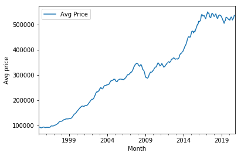

```python
# Plotting avg price increase for particular borough
ax = Barnet_prices.plot(kind = 'line', x = 'Month', y = 'Avg Price')
ax.set_ylabel('Avg price')
```

To limit the number of data points you have, you might want to extract the year from every month value your *Month* column.

To this end, you *could* apply a *lambda function*. Your logic could work as follows:

1. look through the `Month` column
2. extract the year from each individual value in that column
3. store that corresponding year as separate column.

Whether you go ahead with this is up to you. Just so long as you answer our initial brief: which boroughs of London have seen the greatest house price increase, on average, over the past two decades?

```python
# Extracting year form Month Column

prop_final['Year'] = prop_final['Month'].apply(lambda x: x.year)
```

```python
prop_final.head()
```

|  | London_borough | Id | Month | Avg Price | Year |
| --- | --- | --- | --- | --- | --- |
| 1 | Barking & Dagenham | E09000002 | 1995-01-01 | 50460.23 | 1995 |
| 2 | Barnet | E09000003 | 1995-01-01 | 93284.52 | 1995 |
| 3 | Bexley | E09000004 | 1995-01-01 | 64958.09 | 1995 |
| 4 | Brent | E09000005 | 1995-01-01 | 71306.57 | 1995 |
| 5 | Bromley | E09000006 | 1995-01-01 | 81671.48 | 1995 |

# AVERAGE PRICE PER YEAR OVER LAST TWO DECADES

```python
prop_gb = prop_final.groupby(['Year']).mean()
```

```python
prop_gb['Avg Price'] = prop_gb['Avg Price'].astype(float).apply(lambda x: round(x,2))
```

```python
prop_gb.head()
```

| Year | Avg Price |
| --- | --- |
| 1995 | 82325.30 |
| 1996 | 85886.00 |
| 1997 | 98331.69 |
| 1998 | 112116.56 |
| 1999 | 126256.47 |

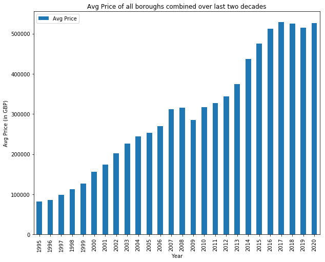

```python
# Plotting avg price increase per year for all boroughs combined
ax = prop_gb.plot(kind = 'bar', figsize = (10,8))
ax.set_xlabel('Year')
ax.set_ylabel('Avg Price (in GBP)')
ax.set_title('Avg Price of all boroughs combined over last two decades')
plt.show()
```

```python
# Grouping by Year and borough for calculating Price ratip
prop_g = prop_final.groupby(['London_borough','Year']).mean()
```

```python
prop_g['Avg Price'] = prop_g['Avg Price'].astype(float).apply(lambda x: round(x,2))
```

```python
prop_g.head()
```

| London_borough | Year | Avg Price |
| --- | --- | --- |
| Barking & Dagenham | 1995 | 51817.97 |
|  | 1996 | 51718.19 |
|  | 1997 | 55974.26 |
|  | 1998 | 60285.82 |
|  | 1999 | 65320.94 |

```python
prop_g = prop_g.reset_index()
```

```python
prop_g.sample(10)
```

|  | London_borough | Year | Avg Price |
| --- | --- | --- | --- |
| 421 | Hounslow | 2000 | 136624.86 |
| 808 | Westminster | 1997 | 165447.59 |
| 108 | Bromley | 1999 | 120874.18 |
| 231 | Enfield | 2018 | 396631.72 |
| 410 | Hillingdon | 2015 | 352748.34 |
| 622 | Newham | 2019 | 363957.16 |
| 3 | Barking & Dagenham | 1998 | 60285.82 |
| 36 | Barnet | 2005 | 279459.67 |
| 425 | Hounslow | 2004 | 215827.15 |
| 795 | Wandsworth | 2010 | 374487.98 |